# Logistic Regression (for classification) part1

This is a supervised learning techinque. Regression has a continuous outcomes.

```r
library(tidyverse)
library(janitor)
```

| tu_score | employed | age | accepted |
| --- | --- | --- | --- |
| 433 | TRUE | 28 | TRUE |
| 93 | TRUE | 52 | FALSE |
| 368 | FALSE | 63 | FALSE |
| 665 | TRUE | 42 | TRUE |
| 687 | TRUE | 38 | TRUE |
| 594 | TRUE | 27 | FALSE |
| 83 | FALSE | 24 | FALSE |
| 172 | TRUE | 19 | FALSE |
| 27 | FALSE | 45 | FALSE |
| 232 | FALSE | 34 | FALSE |

[output cut: 990 more lines]

```r
library(GGally)
```

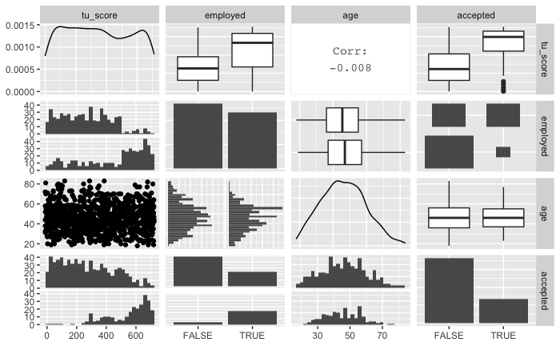

how does acceptance vary with tu score (credit score)

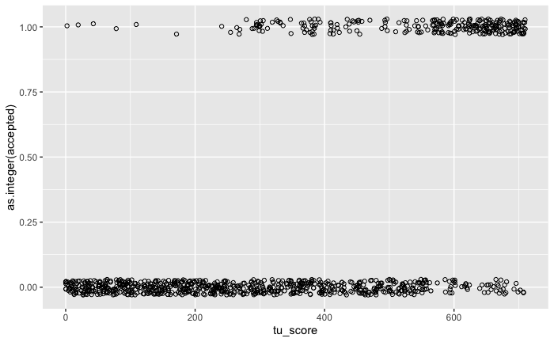

```r
score_plot <- ggplot(mortgage_data)+
  geom_jitter(aes(x = tu_score, y = as.integer(accepted)), shape = 1,
              position = position_jitter(height = 0.03))

score_plot
```

Higher tu_score results in higher chances of mortgage application acceptance.

This is possible to model with LM.

```r
mortgage_data_lin_model <- lm(as.integer(accepted)~tu_score, data = mortgage_data)
mortgage_data_lin_model
```

```
Call:
lm(formula = as.integer(accepted) ~ tu_score, data = mortgage_data)

Coefficients:
(Intercept)     tu_score
  -0.146085     0.001196
```

```r
library(modelr)
```

```r
predict_lin <- tibble(tu_score = seq(0,710,1)) %>%
  add_predictions(mortgage_data_lin_model)
predict_lin
```

| tu_score | pred |
| --- | --- |
| 0 | -0.1460849433 |
| 1 | -0.1448889319 |
| 2 | -0.1436929204 |
| 3 | -0.1424969089 |
| 4 | -0.1413008975 |
| 5 | -0.1401048860 |
| 6 | -0.1389088746 |
| 7 | -0.1377128631 |
| 8 | -0.1365168516 |
| 9 | -0.1353208402 |

[output cut: 701 more lines]

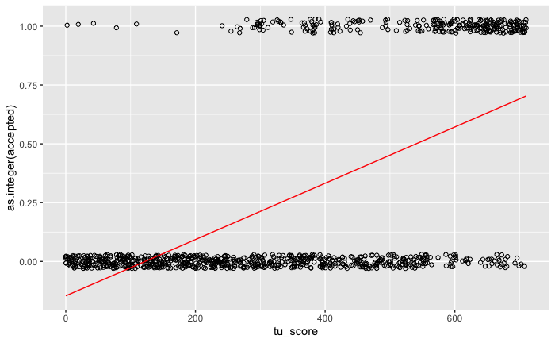

```r
score_plot +
  geom_line(data = predict_lin, aes(x = tu_score, y = pred), col = "red")
```

This is not a good model. Probability should not be less than 0!

#### Logistic function.

Generalised linear model: glm() - after transformation of y we end up with a line.

there are different glm()s, but we are interested in logistic regression.

```r
mortgage_data_logreg_model <- glm(accepted ~ tu_score,
                                  data = mortgage_data, family = binomial(link = "logit"))

mortgage_data_logreg_model
```

```
Call:  glm(formula = accepted ~ tu_score, family = binomial(link = "logit"),
    data = mortgage_data)

Coefficients:
(Intercept)     tu_score
  -4.575035     0.008475

Degrees of Freedom: 999 Total (i.e. Null);  998 Residual
Null Deviance:      1170
Residual Deviance: 792.1    AIC: 796.1
```

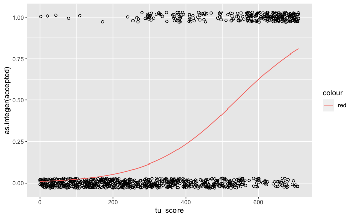

```r
predict_log <- tibble(tu_score = seq(0,710,1)) %>%
  add_predictions(mortgage_data_logreg_model, type = "response")

score_plot +
  geom_line(data = predict_log, aes(x = tu_score, y = pred, col = "red"))
```

tu_score of 594.

```r
mortgage_data %>%
  filter(tu_score == 594)
```

| tu_score | employed | age | accepted |
| --- | --- | --- | --- |
| 594 | TRUE | 27 | FALSE |
| 594 | TRUE | 47 | FALSE |
| 594 | TRUE | 33 | TRUE |
| 594 | TRUE | 36 | TRUE |
| 594 | TRUE | 45 | TRUE |

Probability of being accepted is 3/(2+3) = 3/5 = 6/10 = 0.6

```r
predict_at <- tibble(tu_score = 594) %>%
  add_predictions(mortgage_data_logreg_model, type = "response")
predict_at
```

| tu_score | pred |
| --- | --- |
| 594 | 0.6127971 |

Interpreting coefficient in logistic regression:

(Odds of success after change in x) = exp(b * change in x) * (odds of success before change in x)

```r
predict_at_594 <- tibble(tu_score = 594) %>%
  add_predictions(mortgage_data_logreg_model, type = "response") %>%
  mutate(odds = pred / (1-pred))
predict_at_594
```

| tu_score | pred | odds |
| --- | --- | --- |
| 594 | 0.6127971 | 1.582625 |

```r
mortgage_data_logreg_model
```

```
Call:  glm(formula = accepted ~ tu_score, family = binomial(link = "logit"),
    data = mortgage_data)

Coefficients:
(Intercept)     tu_score
  -4.575035     0.008475

Degrees of Freedom: 999 Total (i.e. Null);  998 Residual
Null Deviance:      1170
Residual Deviance: 792.1    AIC: 796.1
```

odds of success after change of tu_score = exp(0.008475 * change in tu_score) * (odds of success before change in tu_score)

exp(0.008475 * change in tu_score): odds factor

(odds of success before change in tu_score) : odds at 594

change in tu_score = +50

```r
odds_factor <- exp(b*50)
odds_factor
```

```
[1] 1.52768
```

```r
odds_at_644 <- odds_factor * predict_at_594

odds_at_644
```

| tu_score | pred | odds |
| --- | --- | --- |
| 907.4417 | 0.9361577 | 2.417745 |

###### task

How do odds change if tu_score descreased by 50.

```r
task_odds_factor <- (exp(b * (-50)))
odds_at_544 <- task_odds_factor * predict_at_594
task_odds_factor
```

```
[1] 0.6545875
```

```r
odds_at_544
```

| tu_score | pred | odds |
| --- | --- | --- |
| 388.825 | 0.4011293 | 1.035967 |

about 50/50 chances of being accepted.

## multiple predictors.

```r
mortgage_data_multi_logreg_model <- glm(accepted ~ tu_score + employed + age, data = mortgage_data,
                           family = binomial(link = "logit"))
mortgage_data_multi_logreg_model
```

```
Call:  glm(formula = accepted ~ tu_score + employed + age, family = binomial(link = "logit"),
    data = mortgage_data)

Coefficients:
 (Intercept)      tu_score  employedTRUE           age
    -4.62854       0.00673       1.48034      -0.00126

Degrees of Freedom: 999 Total (i.e. Null);  996 Residual
Null Deviance:      1170
Residual Deviance: 740  AIC: 748
```

```r
library(broom)
```

```r
tidy_out <- clean_names(tidy(mortgage_data_multi_logreg_model))
glance_out <- clean_names(glance(mortgage_data_multi_logreg_model))
tidy_out
```

| term | estimate | std_error | statistic | p_value |
| --- | --- | --- | --- | --- |
| (Intercept) | -4.628539329 | 0.4303343969 | -10.7556806 | 5.572114e-27 |
| tu_score | 0.006730118 | 0.0005692479 | 11.8228250 | 2.975086e-32 |
| employedTRUE | 1.480341044 | 0.2114793584 | 6.9999316 | 2.560875e-12 |
| age | -0.001260001 | 0.0070633577 | -0.1783856 | 8.584202e-01 |

```r
glance_out
```

| null_deviance | df_null | log_lik | aic | bic | deviance | df_residual |
| --- | --- | --- | --- | --- | --- | --- |
| 1170.476 | 999 | -369.9771 | 747.9542 | 767.5853 | 739.9542 | 996 |